# cahp2_titanic_lab

## ❇️ 타이타닉 데이터셋을 활용한 전체 분석 워크플로우

- Gemini AI를 이용하여 단계별 진행한다
- 데이터 로드 -> 데이터 파악 및 EDA -> 전처리/정제 -> 모델링 및 평가 -> 대시보드 -> 배포 순으로 진행할 것이다
- 단계별 진행시마다 필요한 모듈을 자동 설치해주거나 설치 여부를 물어본다. 필요 모듈을 설치하면서 진행하면 된다

### 1️⃣ 1단계: 데이터 로드

**✔️ 프롬프트**

- 나의 목표는 타이타닉 데이터셋을 활용하여 생존율에 영향을 미치는 주요 요인을 분석하고, 이를 바탕으로 생존 예측 분석을 대시보드까지 구현하는 것을 목표로 하고 있어
- "data/titanic.csv" 파일을 가지고 EDA, 전처리, 모델링, 대시보드, 배포순으로 진행하려 해. 단계적으로 진행할게
- 1단계로 python 코드로 데이터를 읽어와 줘

```python
# 1단계

import pandas as pd

# 1. 데이터 로드
df = pd.read_csv('data/titanic.csv')

# 2. 데이터 기본 정보 및 결측치 확인
print("--- 데이터 기본 정보 ---")
print(df.info())
print("\n--- 결측치 현황 ---")
print(df.isnull().sum())
```

```
--- 데이터 기본 정보 ---
<class 'pandas.core.frame.DataFrame'>
RangeIndex: 891 entries, 0 to 890
Data columns (total 12 columns):
 #   Column       Non-Null Count  Dtype
---  ------       --------------  -----
 0   PassengerId  891 non-null    int64
 1   Survived     891 non-null    int64
 2   Pclass       891 non-null    int64
 3   Name         891 non-null    object
 4   Sex          891 non-null    object
 5   Age          714 non-null    float64
 6   SibSp        891 non-null    int64
 7   Parch        891 non-null    int64
 8   Ticket       891 non-null    object
 9   Fare         891 non-null    float64
 10  Cabin        204 non-null    object
 11  Embarked     889 non-null    object
dtypes: float64(2), int64(5), object(5)
memory usage: 83.7+ KB
None

--- 결측치 현황 ---
PassengerId      0
Survived         0
Pclass           0
Name             0
Sex              0
Age            177
SibSp            0
Parch            0
Ticket           0
Fare             0
Cabin          687
Embarked         2
dtype: int64
```

### 2️⃣ 2단계: 데이터 파악 및 탐색적 데이터 분석 (EDA)

**✔️ 프롬프트**

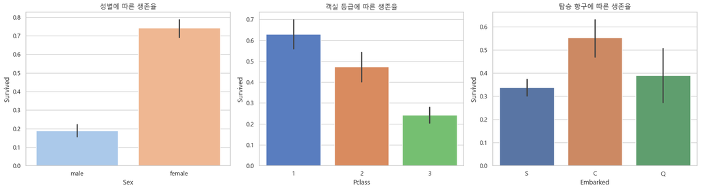

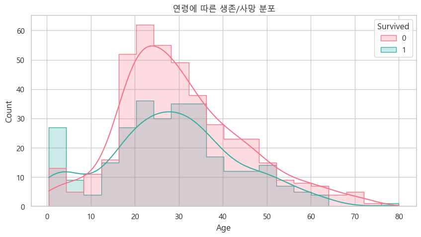

```python
import seaborn as sns
import matplotlib.pyplot as plt

# 시각화 설정
sns.set_theme(style="whitegrid")
plt.rcParams['font.family'] = 'Malgun Gothic' # 윈도우 한글 깨짐 방지

# 3. 주요 변수별 생존율 시각화
fig, axes = plt.subplots(1, 3, figsize=(18, 5))

# (1) 성별에 따른 생존율
sns.barplot(x='Sex', y='Survived', data=df, ax=axes[0], palette='pastel')
axes[0].set_title('성별에 따른 생존율')

# (2) 객실 등급(Pclass)에 따른 생존율
sns.barplot(x='Pclass', y='Survived', data=df, ax=axes[1], palette='muted')
axes[1].set_title('객실 등급에 따른 생존율')

# (3) 탑승 항구(Embarked)에 따른 생존율
sns.barplot(x='Embarked', y='Survived', data=df, ax=axes[2], palette='deep')
axes[2].set_title('탑승 항구에 따른 생존율')

plt.tight_layout()
plt.show()

# 4. 연령대별 생존 분포 (히스토그램)
plt.figure(figsize=(10, 5))
sns.histplot(data=df, x='Age', hue='Survived', kde=True, element='step', palette='husl')
plt.title('연령에 따른 생존/사망 분포')
plt.show()
```

### 3️⃣ 3단계: 데이터 전처리 (Data Cleaning & Engineering)

**✔️ 프롬프트**

- 3단계는 다음에 따라 처리한다
  1. 결측치 처리: 나이(Age)는 객실 등급(Pclass)과 성별(Sex)별 중앙값으로 채우고, 승선 항구(Embarked)는 최빈값으로 채운다.
  2. 컬럼 삭제: 객실 번호(Cabin)는 결측치가 너무 많아 삭제하고, 고유 식별자 역할을 하는 PassengerId와 Ticket도 분석에 필요 없으므로 삭제한다.
  3. 새로운 컬럼 추가: Name 컬럼에서 호칭(Mr, Mrs, Miss 등)을 추출하여 Title 컬럼을 추가하고, 가족 수를 나타내는 Family 컬럼을 SibSp와 Parch를 합쳐서 추가한다.
  4. 범주형 데이터 변환 (Encoding): 머신러닝 모델이 이해할 수 있는 숫자 형태로 변환한다.성별(Sex)을 숫자(male: 0, female: 1)로 변환한다

```python
# --- 1. 결측치 처리 ---
# 나이(Age)는 객실 등급(Pclass)과 성별(Sex)별 중앙값으로 채움
df['Age'] = df['Age'].fillna(df.groupby(['Pclass', 'Sex'])['Age'].transform('median'))

# 승선 항구(Embarked)는 최빈값(S)으로 채움
embarked_mode = df['Embarked'].mode()[0]
df['Embarked'] = df['Embarked'].fillna(embarked_mode)

# --- 2. 컬럼 삭제 ---
# 결측치가 너무 많은 Cabin과 식별자 성격의 PassengerId, Ticket 삭제
df.drop(['Cabin', 'PassengerId', 'Ticket'], axis=1, inplace=True)

# --- 3. 새로운 컬럼 추가 ---
# Name에서 호칭(Title) 추출 (Mr, Mrs, Miss 등)
df['Title'] = df['Name'].str.extract(' ([A-Za-z]+)\.', expand=False)

# 가족 수(Family) 컬럼 추가 (형제자매/배우자 + 부모/자녀 + 본인)
df['Family'] = df['SibSp'] + df['Parch'] + 1

# --- 4. 범주형 데이터 변환 (Encoding) ---
# 성별(Sex) 변환: male -> 0, female -> 1
df['Sex'] = df['Sex'].map({'male': 0, 'female': 1})

# (추가 팁) 분석에 사용하지 않는 Name 컬럼은 이제 삭제해도 무방합니다.
df.drop('Name', axis=1, inplace=True)

# 결과 확인
print("--- 전처리 후 데이터 정보 ---")
print(df.info())
print("\n--- 전처리 후 상위 5개 데이터 ---")
print(df.head())
```

```
--- 전처리 후 데이터 정보 ---
<class 'pandas.core.frame.DataFrame'>
RangeIndex: 891 entries, 0 to 890
Data columns (total 10 columns):
 #   Column    Non-Null Count  Dtype
---  ------    --------------  -----
 0   Survived  891 non-null    int64
 1   Pclass    891 non-null    int64
 2   Sex       891 non-null    int64
 3   Age       891 non-null    float64
 4   SibSp     891 non-null    int64
 5   Parch     891 non-null    int64
 6   Fare      891 non-null    float64
 7   Embarked  891 non-null    object
 8   Title     891 non-null    object
 9   Family    891 non-null    int64
dtypes: float64(2), int64(6), object(2)
memory usage: 69.7+ KB
None

--- 전처리 후 상위 5개 데이터 ---
   Survived  Pclass  Sex   Age  SibSp  Parch     Fare Embarked Title  Family
0         0       3    0  22.0      1      0   7.2500        S    Mr       2
1         1       1    1  38.0      1      0  71.2833        C   Mrs       2
2         1       3    1  26.0      0      0   7.9250        S  Miss       1
3         1       1    1  35.0      1      0  53.1000        S   Mrs       2
4         0       3    0  35.0      0      0   8.0500        S    Mr       1
```

### 4️⃣ 4단계 : 모델링 및 평가

**✔️ 프롬프트**

- 4단계 모델링 및 평가 : 랜덤 포레스트(Random Forest) 알고리즘으로 생존 여부를 예측하는 머신러닝 모델을 만들고 성능을 평가해줘

```python
import pandas as pd
from sklearn.model_selection import train_test_split
from sklearn.ensemble import RandomForestClassifier
from sklearn.metrics import accuracy_score, classification_report
from sklearn.preprocessing import LabelEncoder

# 1. 전처리된 데이터 준비 (이전 단계의 연속)
# 위에서 수행한 Title 추출 및 인코딩 과정을 포함합니다.
df['Title'] = df['Title'].replace(['Lady', 'Countess','Capt', 'Col','Don', 'Dr', 'Major', 'Rev', 'Sir', 'Jonkheer', 'Dona'], 'Rare')
df['Title'] = df['Title'].replace('Mlle', 'Miss').replace('Ms', 'Miss').replace('Mme', 'Mrs')

# 나머지 범주형 변수(Title, Embarked) 수치화
le = LabelEncoder()
df['Title'] = le.fit_transform(df['Title'])
df['Embarked'] = le.fit_transform(df['Embarked'])

# 2. 독립변수(X)와 종속변수(y) 분리
X = df.drop('Survived', axis=1)
y = df['Survived']

# 3. 학습 데이터와 테스트 데이터 분리 (8:2 비율)
X_train, X_test, y_train, y_test = train_test_split(X, y, test_size=0.2, random_state=42)

# 4. 모델 생성 및 학습 (Random Forest)
model = RandomForestClassifier(n_estimators=100, random_state=42)
model.fit(X_train, y_train)

# 5. 예측 및 평가
y_pred = model.predict(X_test)

print(f"모델 정확도(Accuracy): {accuracy_score(y_test, y_pred):.4f}")
print("\n--- 상세 평가 보고서 ---")
print(classification_report(y_test, y_pred))

# 6. 특성 중요도(Feature Importance) 확인
importances = pd.Series(model.feature_importances_, index=X.columns).sort_values(ascending=False)
print("\n--- 변수 중요도 ---")
print(importances)
```

```
모델 정확도(Accuracy): 0.8324

--- 상세 평가 보고서 ---
              precision    recall  f1-score   support

           0       0.86      0.86      0.86       105
           1       0.80      0.80      0.80        74

    accuracy                           0.83       179
   macro avg       0.83      0.83      0.83       179
weighted avg       0.83      0.83      0.83       179


--- 변수 중요도 ---
Fare        0.242023
Sex         0.223788
Age         0.215806
Title       0.097265
Pclass      0.076199
Family      0.055557
SibSp       0.033829
Embarked    0.032716
Parch       0.022817
dtype: float64
```

### 5️⃣ 결과 요약 및 대시보드 기획 (Streamlit 연계)

**✔️ 프롬프트**

- 4단계 대시보드(Dashboard) 구현 : 전체 데이터 인사이트와 생존 예측 시뮬레이터 2개의 탭으로 구성한 대시보드
  1. 사이드바 : 객실등급, 성별, 탑승항구로 필터링 추가
  2. Tab 1: 데이터 인사이트
     - 객실 등급별, 성별/연령대별 생존율 시각화
     - 사이드바 필터를 통한 동적 데이터 탐색
  3. Tab 2: 생존 예측 시뮬레이터
     - 사용자가 직접 정보를 입력(성별, 나이 등)
     - 머신러닝 모델이 실시간으로 생존 확률 계산 및 게이지 차트 표시

**✔️ streamlit 실행**

- 완성된 코드를 app.py 파일에 저장하고 터미널에서 streamlit run app.py로 실행한다
- 주소를 ctrl+ 클릭하여 새 창에 띄워진 페이지 확인한다
- 터미널에서 실행 중단은 ctrl + C 키

```python
import streamlit as st
import pandas as pd
import plotly.express as px
import plotly.graph_objects as go
from sklearn.ensemble import RandomForestClassifier

# 1. 페이지 설정
st.set_page_config(page_title="타이타닉 종합 대시보드", layout="wide")

# --- 2. 디자인 개선 (탭 글자 크기 및 스타일) ---
st.markdown("""
    <style>
        /* 탭 텍스트 크기 확대 및 강조 */
        .stTabs [data-baseweb="tab-list"] button [data-testid="stMarkdownContainer"] p {
            font-size: 16px;
            font-weight: bold;
            color: #31333F;
        }

        /* 탭 메뉴 간격 및 테두리 */
        .stTabs [data-baseweb="tab-list"] {
            gap: 15px;
            border-bottom: 2px solid #e0e0e0;
        }

        /* 탭 버튼 배경 및 라운딩 */
        .stTabs [data-baseweb="tab"] {
            height: 55px;
            background-color: #f9f9f9;
            border-radius: 8px 8px 0px 0px;
            padding: 0px 30px;
        }

        /* 선택된 활성 탭 스타일 */
        .stTabs [aria-selected="true"] {
            background-color: #f0f7ff !important;
            border-bottom: 4px solid #007bff !important;
        }
    </style>
""", unsafe_allow_html=True)

# 3. 데이터 로드 및 전처리
@st.cache_data
def load_data():
    df = pd.read_csv('titanic.csv')
    # 전처리: 결측치 및 변수 생성
    df['Title'] = df['Name'].str.extract(' ([A-Za-z]+)\.', expand=False)
    df['Age'] = df['Age'].fillna(df.groupby('Title')['Age'].transform('median'))
    df['Age'] = df['Age'].fillna(df['Age'].median())
    df['Embarked'] = df['Embarked'].fillna(df['Embarked'].mode()[0])

    # 항구 이름 가독성 개선
    embarked_map = {'S': 'Southampton', 'C': 'Cherbourg', 'Q': 'Queenstown'}
    df['Embarked_Full'] = df['Embarked'].map(embarked_map)

    # 연령대 그룹
    bins = [0, 12, 18, 35, 60, 100]
    labels = ['어린이', '청소년', '청년', '중년', '노년']
    df['AgeGroup'] = pd.cut(df['Age'], bins=bins, labels=labels)

    # 모델용 인코딩
    df['Sex_Code'] = df['Sex'].map({'male': 0, 'female': 1})
    return df

df = load_data()

# 4. 머신러닝 모델 학습
@st.cache_resource
def train_model(data):
    X = data[['Pclass', 'Sex_Code', 'Age', 'SibSp', 'Parch', 'Fare']]
    y = data['Survived']
    model = RandomForestClassifier(n_estimators=100, random_state=42)
    model.fit(X, y)
    return model

model = train_model(df)

# --- 5. 사이드바 필터 설정 (객실 등급, 성별, 탑승 항구) ---
st.sidebar.header("🔍 데이터 분석 필터")
st.sidebar.write("대시보드 차트에 적용될 조건을 선택하세요.")

# 객실 등급 필터
selected_pclass = st.sidebar.multiselect(
    "1. 객실 등급 선택",
    options=sorted(df['Pclass'].unique()),
    default=df['Pclass'].unique()
)

# 성별 필터
selected_sex = st.sidebar.multiselect(
    "2. 성별 선택",
    options=df['Sex'].unique(),
    default=df['Sex'].unique()
)

# 탑승 항구 필터 (추가됨)
selected_embarked = st.sidebar.multiselect(
    "3. 탑승 항구 선택",
    options=df['Embarked_Full'].unique(),
    default=df['Embarked_Full'].unique()
)

# 데이터 필터링 적용
filtered_df = df[
    (df['Pclass'].isin(selected_pclass)) &
    (df['Sex'].isin(selected_sex)) &
    (df['Embarked_Full'].isin(selected_embarked))
]

# --- 6. 메인 레이아웃 및 탭 구성 ---
st.title("🚢 타이타닉 생존 인사이트 대시보드")

tab1, tab2 = st.tabs(["📊 데이터 분석 대시보드", "🔮 생존 예측 시뮬레이터"])

# --- Tab 1: 분석 대시보드 ---
with tab1:
    st.subheader("📍 필터 결과 요약")

    # 상단 지표(Metrics)
    m1, m2, m3, m4 = st.columns(4)
    m1.metric("승객 수", f"{len(filtered_df)}명")
    m2.metric("평균 생존율", f"{filtered_df['Survived'].mean():.1%}")
    m3.metric("평균 연령", f"{filtered_df['Age'].mean():.1f}세")
    m4.metric("평균 운임", f"${filtered_df['Fare'].mean():.1f}")

    st.divider()

    #차트 섹션
    row1_col1, row1_col2 = st.columns(2)

    with row1_col1:
        st.subheader("📊 객실 등급별 생존자 수")
        fig1 = px.histogram(filtered_df, x="Pclass", color="Survived",
                            barmode="group", color_discrete_map={0: "red", 1: "green"},
                            labels={'Survived': '생존 여부 (0:사망, 1:생존)'})
        st.plotly_chart(fig1, use_container_width=True)

    with row1_col2:
        st.subheader("👧 성별 및 연령대별 생존율")
        # 생존율 계산을 위한 집계
        survival_by_age = filtered_df.groupby(['AgeGroup', 'Sex'], as_index=False)['Survived'].mean()
        fig2 = px.bar(survival_by_age, x="AgeGroup", y="Survived", color="Sex",
                    barmode="group", title="연령대별 생존 확률")
        st.plotly_chart(fig2, use_container_width=True)

    row2_col1, row2_col2 = st.columns(2)

    with row2_col1:
        st.subheader("💰 요금(Fare)과 생존의 관계")
        fig3 = px.box(filtered_df, x="Survived", y="Fare", color="Survived",
                    points="all", title="생존 여부에 따른 요금 분포")
        st.plotly_chart(fig3, use_container_width=True)

    with row2_col2:
        st.subheader("📍 탑승 항구별 승객 분포")
        embarked_counts = filtered_df['Embarked'].value_counts().reset_index()
        fig4 = px.pie(embarked_counts, values='count', names='Embarked', hole=0.4)
        st.plotly_chart(fig4, use_container_width=True)

    # 데이터 테이블 확인
    if st.checkbox("전체 데이터 보기"):
        st.dataframe(filtered_df)


# --- Tab 2: 생존 예측 시뮬레이터 ---
with tab2:
    st.subheader("🕵️ AI 생존 확률 시뮬레이션")
    st.write("승객의 세부 정보를 입력하면 AI가 생존 가능성을 실시간으로 계산합니다.")

    c1, c2 = st.columns([1, 1.5])

    with c1:
        # 시뮬레이터 입력창
        i_sex = st.radio("성별", ["여성", "남성"], horizontal=True)
        i_class = st.select_slider("객실 등급", options=[1, 2, 3], value=1)
        i_age = st.slider("나이", 0, 80, 25)
        i_fare = st.number_input("지불 요금 ($)", 0, 500, 30)
        i_fam = st.slider("동반 가족 수", 0, 10, 0)

        # 모델 입력 데이터 변환
        sex_val = 1 if i_sex == "여성" else 0
        input_data = pd.DataFrame([[i_class, sex_val, i_age, i_fam, 0, i_fare]],
                                  columns=['Pclass', 'Sex_Code', 'Age', 'SibSp', 'Parch', 'Fare'])

        # 예측 수행
        prob = model.predict_proba(input_data)[0][1] * 100

    with c2:
        # 생존 확률 시각화 (게이지)
        fig_gauge = go.Figure(go.Indicator(
            mode = "gauge+number",
            value = prob,
            title = {'text': f"예상 생존 확률", 'font': {'size': 24}},
            gauge = {
                'axis': {'range': [0, 100]},
                'bar': {'color': "#1f77b4"},
                'steps': [
                    {'range': [0, 50], 'color': "#f8d7da"},
                    {'range': [50, 100], 'color': "#d4edda"}]
            }
        ))
        st.plotly_chart(fig_gauge, use_container_width=True)

        if prob >= 50:
            st.success(f"결과: 이 조건의 승객은 **생존 가능성**이 높습니다! ({prob:.1f}%)")
        else:
            st.error(f"결과: 이 조건의 승객은 **사망 가능성**이 높습니다. ({prob:.1f}%)")
```